# Data Cleaning - ML Assignment

BG

September 7, 2016

## Introduction

```r
library(caret)
library(AppliedPredictiveModeling)
set.seed(12331)
```

## Data Cleaning

```r
setwd("C:/Users/bag9031/Documents/Personal/Coursera - ML")
pml1<-read.csv(sep=",", header=TRUE, "pml-training.csv",na.string=c("NA", ""))
dim(pml1)
for(i in 1:160) {h1[i]<-length(pml1[,i][pml1[,i]=='NA'])}
df<-data.frame(names(pml1), h1)
colnames(df)<-c("name","count")
df2<-subset(df, count==0)
pml2<-pml1[,as.character(df2$name)]
pml2<-pml2[,c(-1:-7)] # Remove columns pertaining to user (name, time window etc.)
dim(pml2)
write.table(pml2, "C:/Users/bag9031/Documents/Personal/Coursera - ML/Testpml" ) ## save file as table for future use
```

[output not shown]

## Read data and split into Training and Validation sets

```r
setwd("C:/Users/bag9031/Documents/Personal/Coursera - ML")
p<-read.table("Testpml")
pml2<-as.data.frame(p)
dim(pml2)
```

```
## [1] 19622    53
```

```r
intrain<-createDataPartition(pml2$classe, list=FALSE,p=0.3)
pmlval<-pml2[-intrain,] ## create validation set
pmltemp<-pml2[intrain,] ## Use remaining data to create Training & Test Data
pmltrain<-pmltemp

dim(pmltrain)
```

```
## [1] 5889   53
```

```r
dim(pmlval) # Display dimensions of Training and Validation sets
```

```
## [1] 13733    53
```

## Dimension Reduction using PCA

Cleaned data still consists of 52 predictors and 1 outcome variable (classe). Dimension reduction was performed understand if fewer covariates can be utilized for prediction of the outcome variable. PCA model was created and then utilized to convert the training and validation data into principal components (PCs). Prior to creating PCs, the summary of PCA was evaluated to understand the variance explained (plot provided).

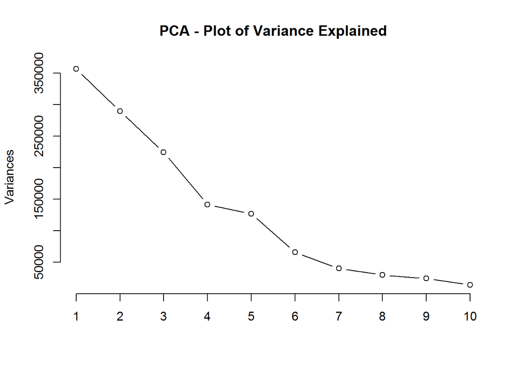

```r
pcaanalysis<-prcomp(pmltrain[,-53]) # 53rd column is the output variable and hence was excluded from the PCA ;
plot(pcaanalysis, type="l",main="PCA - Plot of Variance Explained")
```

```r
pcamodel<-preProcess(pmltrain[,-53], method="pca",pcaComp=52) # Run principal components analysis
trainpcadata<-predict(pcamodel, pmltrain[,-53]) # Create principal components for training data
valpcadata<-predict(pcamodel, pmlval[,-53]) # Create principal components for training data
```

## Set Tuning Parameters for Cross Validation

```r
fitcontrolrbf<-trainControl(method="cv", number = 10) # Setting control parameters for the SVM training; 10 Fold, cross validation
fitcontrollinear<-trainControl(method="repeatedcv", number = 10, repeats =3) # Setting control parameters for the SVM training; 3 Fold, repeated cross validation
```

## Training RBF Kernel SVM Parameters

First SVM is run with RBF kernel to determine the possible values of ‘C’ & ‘Sigma’ parameters.The best values were then used to run the model and determine the accuracy

```r
svm.tune<-train(x=trainpcadata, y=pmltrain$classe, method = "svmRadial",tuneLength =9, trControl=fitcontrolrbf)#best parameters can be identified by svm.tune$best
grid<-expand.grid(sigma = c(0.01308048), C= c(32)) # select best tuning parameters for the SVM
svm.tune2<-train(x=trainpcadata, y=pmltrain$classe, method = "svmRadial",tuneGrid=grid, trControl=fitcontrolrbf)
svm.tune2
```

```
## Support Vector Machines with Radial Basis Function Kernel
##
## 5889 samples
##   52 predictor
##    5 classes: 'A', 'B', 'C', 'D', 'E'
##
## No pre-processing
## Resampling: Cross-Validated (10 fold)
## Summary of sample sizes: 5301, 5300, 5299, 5300, 5300, 5301, ...
## Resampling results
##
##   Accuracy   Kappa      Accuracy SD  Kappa SD
##   0.9762294  0.9699252  0.009154616  0.01158554
##
## Tuning parameter 'sigma' was held constant at a value of 0.01308048
##
## Tuning parameter 'C' was held constant at a value of 32
##
```

```r
## CV In-sample Accuracy (including all Principal Components: 98%
```

## Training SVM Linear Kernel Parameters

```r
svmlinear.tune<-train(x=trainpcadata, y=pmltrain$classe, method = "svmLinear",tuneLength =9, trControl=fitcontrollinear) # Use the Linear Kernel for the SVM vector
svmlinear.tune
```

```
## Support Vector Machines with Linear Kernel
##
## 5889 samples
##   52 predictor
##    5 classes: 'A', 'B', 'C', 'D', 'E'
##
## No pre-processing
## Resampling: Cross-Validated (10 fold, repeated 3 times)
## Summary of sample sizes: 5300, 5299, 5301, 5300, 5299, 5301, ...
## Resampling results
##
##   Accuracy   Kappa      Accuracy SD  Kappa SD
##   0.7833869  0.7248456  0.01670869   0.02124718
##
## Tuning parameter 'C' was held constant at a value of 1
##
```

## Out of Sample Error Estimation for SVM w RBF Kernel

Out of Sample Accuracy & Error were estimated using the Validation (Test) data set previously created. First Out of Sample Error was estimated for the SVM model with RBF Kernel

```r
cfmmatrixsvmrbf<-confusionMatrix(pmlval$classe, predict(svm.tune2, newdata=valpcadata))
cfmmatrixsvmrbf
```

```
## Confusion Matrix and Statistics
##
##           Reference
## Prediction    A    B    C    D    E
##          A 3859   24    8    0   15
##          B   38 2584   25    0   10
##          C    3   33 2328   22    9
##          D    2    1   75 2165    8
##          E    5   14   10    3 2492
##
## Overall Statistics
##
##                Accuracy : 0.9778
##                  95% CI : (0.9752, 0.9802)
##     No Information Rate : 0.2845
##     P-Value [Acc > NIR] : < 2.2e-16
##
##                   Kappa : 0.9719
##  Mcnemar's Test P-Value : 1.17e-06
##
## Statistics by Class:
##
##                      Class: A Class: B Class: C Class: D Class: E
## Sensitivity            0.9877   0.9729   0.9518   0.9886   0.9834
## Specificity            0.9952   0.9934   0.9941   0.9925   0.9971
## Pos Pred Value         0.9880   0.9725   0.9720   0.9618   0.9873
## Neg Pred Value         0.9951   0.9935   0.9896   0.9978   0.9963
## Prevalence             0.2845   0.1934   0.1781   0.1595   0.1845
## Detection Rate         0.2810   0.1882   0.1695   0.1576   0.1815
## Detection Prevalence   0.2844   0.1935   0.1744   0.1639   0.1838
## Balanced Accuracy      0.9915   0.9832   0.9729   0.9906   0.9903
```

Error for SVM w RBF Kernel is

```r
err1svmrbf<-1-as.numeric(cfmmatrixsvmrbf$overall[1])
err1svmrbf
```

```
## [1] 0.02220928
```

## Out of Sample Error Estimation for SVM w Linear Kernel

Out of Sample Accuracy & Error for the Linear Kernel RBFwere estimated using the Validation (Test) data set previously created.

```r
cfmmatrixsvmlinear<-confusionMatrix(pmlval$classe, predict(svmlinear.tune, newdata=valpcadata))
cfmmatrixsvmlinear
```

```
## Confusion Matrix and Statistics
##
##           Reference
## Prediction    A    B    C    D    E
##          A 3616   85   99   88   18
##          B  308 1923  157   41  228
##          C  158  225 1891   66   55
##          D  128   91  228 1713   91
##          E  149  296  153  165 1761
##
## Overall Statistics
##
##                Accuracy : 0.794
##                  95% CI : (0.7871, 0.8007)
##     No Information Rate : 0.3174
##     P-Value [Acc > NIR] : < 2.2e-16
##
##                   Kappa : 0.7383
##  Mcnemar's Test P-Value : < 2.2e-16
##
## Statistics by Class:
##
##                      Class: A Class: B Class: C Class: D Class: E
## Sensitivity            0.8295   0.7340   0.7480   0.8263   0.8179
## Specificity            0.9691   0.9340   0.9550   0.9539   0.9341
## Pos Pred Value         0.9258   0.7237   0.7896   0.7610   0.6977
## Neg Pred Value         0.9244   0.9371   0.9438   0.9686   0.9650
## Prevalence             0.3174   0.1908   0.1841   0.1510   0.1568
## Detection Rate         0.2633   0.1400   0.1377   0.1247   0.1282
## Detection Prevalence   0.2844   0.1935   0.1744   0.1639   0.1838
## Balanced Accuracy      0.8993   0.8340   0.8515   0.8901   0.8760
```

Error for SVM w Linear Kernel is

```r
err1svmlinear<-1-as.numeric(cfmmatrixsvmlinear$overall[1])
err1svmlinear
```

```
## [1] 0.2060001
```